# Developing methods for identifying the inflection point of a convex/concave curve

Demetris T. Christopoulos

25/6/2019

## The Fisher-Pry sigmoid curve with total symmetry (not noisy)

Let’ s take the function:
$$f (x) = 5 +
5\, tanh (x − 5)$$
after [3], which has p = 5, L = 10, x1 = 2.7024, x99 = 7.2976 and examine it at the interval [2, 8] in order to have data symmetry w.r.t. inflection point. The function is also symmetrical around inflection point, i.e. we have total symmetry.

From Corollary 1.1 of [1] we compute $x_l = 5.970315941, x_r = 4.029684059$, $x_{F1} = 3.850750196, x_{F2} = 6.149249804$, all inside [2, 8], thus all methods are theoretically applicable.

We first take n = 500 sub-intervals equal spaced without error just for checking our estimators. The results are presented at Table 1 of [1], while here we also present the BESE iterations done by ‘bese()’.

```r
library(inflection)
data("table_01")
x=table_01$x
y=table_01$y
plot(x,y,cex=0.3,pch=19)
grid()
bb=ese(x,y,0);bb
```

```
##      j1  j2 chi
## ESE 170 332   5
```

```r
pese=bb[,3];pese
```

```
## [1] 5
```

```r
abline(v=pese)
cc=bese(x,y,0)
cc$iplast
```

```
## [1] 5
```

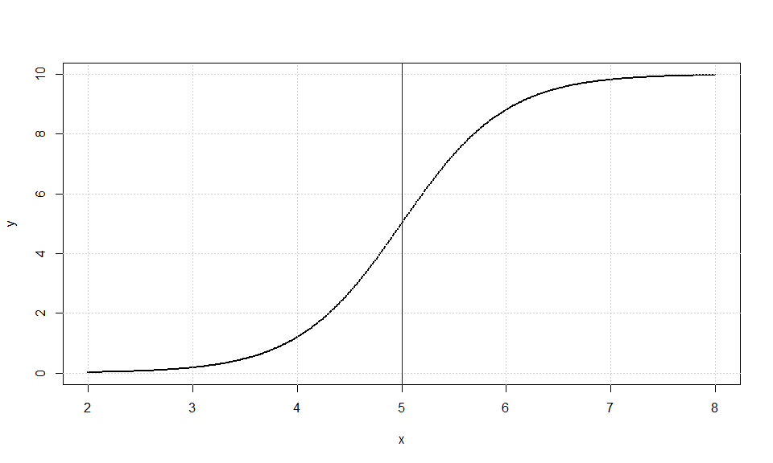

```r
abline(v=cc$iplast,col='blue')
```

```r
knitr::kable(cc$iters, caption = 'BESE')
```

BESE

| n | a | b | ESE |
| --- | --- | --- | --- |
| 501 | 2.000 | 8.000 | 5 |
| 163 | 4.556 | 5.444 | 5 |
| 75 | 4.784 | 5.216 | 5 |
| 37 | 4.892 | 5.108 | 5 |
| 19 | 4.952 | 5.048 | 5 |
| 9 | 4.976 | 5.024 | 5 |
| 5 | 4.988 | 5.012 | 5 |

We observe that $\chi_l = 5.9720, \chi_r = 4.0280$, $\chi_{F1} = 3.8480, \chi_{F2} =6.1520$ are very close to the theoretically expected values, so we are on the results of Lemma 1.3 of [1]. The absolutely accuracy from the first apply of all methods confirms our theoretical analysis.

## The Fisher-Pry sigmoid curve with total symmetry (noisy)

We next add the error term $\epsilon_i\sim\,U(−0.05, 0.05)$ via the process 14 of [1] and run our algorithms again.The results are presented at Table 2 of [1] and here we also present the BESE iterations done by ‘bese()’.

```r
library(inflection)
data("table_02")
x=table_01$x
y=table_01$y
plot(x,y,cex=0.3,pch=19)
grid()
bb=ese(x,y,0);bb
```

```
##      j1  j2 chi
## ESE 170 332   5
```

```r
pese=bb[,3];pese
```

```
## [1] 5
```

```r
abline(v=pese)
cc=bese(x,y,0)
cc$iplast
```

```
## [1] 5
```

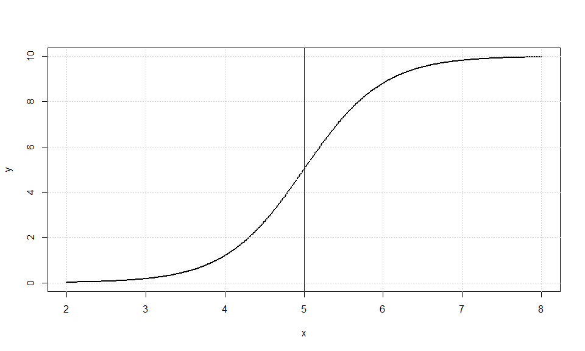

```r
abline(v=cc$iplast,col='blue')
```

```r
knitr::kable(cc$iters, caption = 'BESE')
```

BESE

| n | a | b | ESE |
| --- | --- | --- | --- |
| 501 | 2.000 | 8.000 | 5 |
| 163 | 4.556 | 5.444 | 5 |
| 75 | 4.784 | 5.216 | 5 |
| 37 | 4.892 | 5.108 | 5 |
| 19 | 4.952 | 5.048 | 5 |
| 9 | 4.976 | 5.024 | 5 |
| 5 | 4.988 | 5.012 | 5 |

## The Fisher-Pry sigmoid curve with data left asymmetry (not noisy)

We continue with the same sigmoid function, but now we choose a proper [a, b] to show data asymmetry w.r.t. inflection point.

```r
data("table_03_04")
x=table_03_04$x
y=table_03_04$y
tese=ese(x,y,0);tese
```

```
##     j1  j2    chi
## ESE  2 156 4.7928
```

```r
pese=tese[,3]
tede=ede(x,y,0);tede
```

```
##     j1  j2    chi
## EDE  1 234 5.0854
```

```r
pede=tede[,3]
cc=bese(x,y,0)
cc$iplast
```

```
## [1] 5.0018
```

```r
dd=bede(x,y,0)
dd$iplast
```

```
## [1] 4.998
```

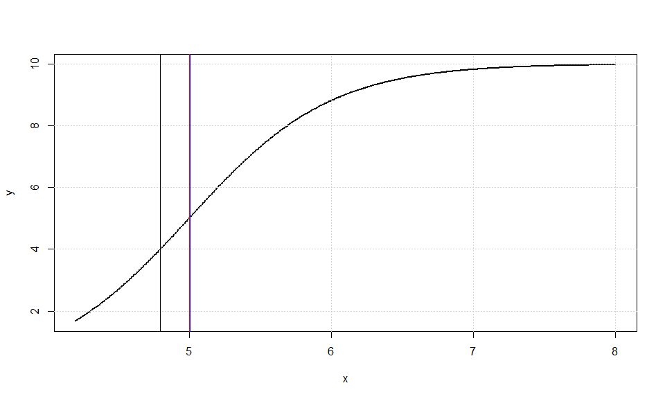

BESE

| n | a | b | ESE |
| --- | --- | --- | --- |
| 501 | 4.2000 | 8.0000 | 4.7928 |
| 155 | 4.8156 | 5.3704 | 5.0930 |
| 74 | 4.8232 | 5.0892 | 4.9562 |
| 36 | 4.9524 | 5.0816 | 5.0170 |
| 18 | 4.9600 | 5.0208 | 4.9904 |
| 9 | 4.9904 | 5.0132 | 5.0018 |

BEDE

| n | a | b | EDE |
| --- | --- | --- | --- |
| 501 | 4.2000 | 8.0000 | 5.0854 |
| 234 | 4.5192 | 5.4844 | 5.0018 |
| 128 | 4.7244 | 5.2716 | 4.9980 |
| 73 | 4.8460 | 5.1576 | 5.0018 |
| 42 | 4.9068 | 5.0892 | 4.9980 |
| 25 | 4.9448 | 5.0512 | 4.9980 |
| 15 | 4.9676 | 5.0284 | 4.9980 |
| 9 | 4.9828 | 5.0208 | 5.0018 |
| 6 | 4.9904 | 5.0132 | 5.0018 |
| 4 | 4.9904 | 5.0056 | 4.9980 |

## The Fisher-Pry sigmoid curve with data left asymmetry (noisy)

Let’ s add again an same error term $\epsilon_i\sim\,U(−0.05, 0.05)$ and run our algorithms. The results at Table 5 of [1] clearly are close enough to the theoretical expectations. Since ESE method did not estimate the inflection point with acceptable accuracy, after running BESE and BEDE iterative methods we find Table 6 of [1] which is a clear improvement of both estimations.

```r
data("table_05_06")
x=table_05_06$x
y=table_05_06$y
tese=ese(x,y,0);tese
```

```
##     j1  j2  chi
## ESE  3 149 4.77
```

```r
pese=tese[,3]
tede=ede(x,y,0);tede
```

```
##     j1  j2    chi
## EDE  3 231 5.0816
```

```r
pede=tede[,3]
cc=bese(x,y,0)
cc$iplast
```

```
## [1] 5.036
```

```r
dd=bede(x,y,0)
dd$iplast
```

```
## [1] 4.9828
```

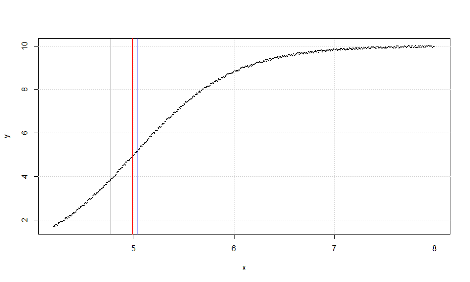

```r
plot(x,y,cex=0.3,pch=19)
grid()
abline(v=pese)
abline(v=cc$iplast,col='blue')
abline(v=dd$iplast,col='red')
```

```r
knitr::kable(cc$iters, caption = 'BESE')
```

BESE

| n | a | b | ESE |
| --- | --- | --- | --- |
| 501 | 4.2000 | 8.0000 | 4.7700 |
| 147 | 4.8156 | 5.2792 | 5.0474 |
| 62 | 4.9144 | 5.1576 | 5.0360 |

```r
knitr::kable(dd$iters, caption = 'BEDE')
```

BEDE

| n | a | b | EDE |
| --- | --- | --- | --- |
| 501 | 4.2000 | 8.0000 | 5.0816 |
| 229 | 4.5268 | 5.5148 | 5.0208 |
| 131 | 4.7244 | 5.2412 | 4.9828 |

## The Gompertz non symmetric sigmoid curve (not noisy)

Let’ s examine the function:
$$f (x) = 10
e^{-e^{5}e^{−x}}$$
after [4], in the interval [3.5, 8]. It is easy to prove that f is (0.224, 1.0)-asymptotically symmetric around inflection point, so we can handle it similar to a symmetric sigmoid only for a distance of ±1 from p = 5.

We use, for comparison reasons, the same SP with 500 sub-intervals without error and obtain the Table 8 of [1] which is absolutely compatible with theoretical predictions. The ESE & EDE iterations are showed at Table 9 of [1] where we observe convergence to the real p for both two methods.

```r
data("table_08_09")
x=table_08_09$x
y=table_08_09$y
tese=ese(x,y,0);tese
```

```
##     j1  j2   chi
## ESE 72 266 5.012
```

```r
pese=tese[,3]
tede=ede(x,y,0);tede
```

```
##     j1  j2   chi
## EDE 67 311 5.192
```

```r
pede=tede[,3]
cc=bese(x,y,0)
cc$iplast
```

```
## [1] 4.9985
```

```r
dd=bede(x,y,0)
dd$iplast
```

```
## [1] 4.9985
```

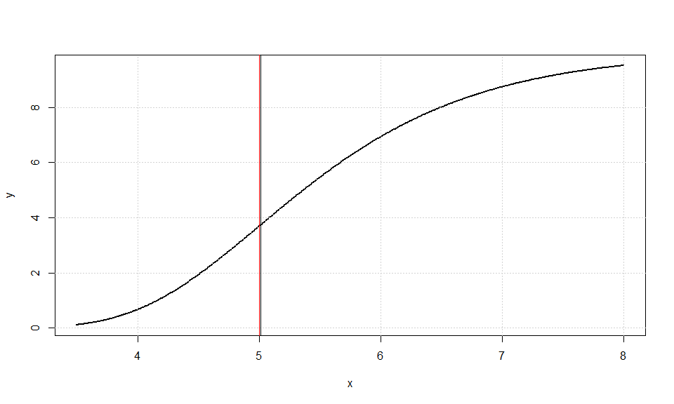

BESE

| n | a | b | ESE |
| --- | --- | --- | --- |
| 501 | 3.500 | 8.000 | 5.0120 |
| 195 | 4.625 | 5.489 | 5.0570 |
| 97 | 4.778 | 5.201 | 4.9895 |
| 48 | 4.904 | 5.120 | 5.0120 |
| 25 | 4.940 | 5.048 | 4.9940 |
| 13 | 4.976 | 5.030 | 5.0030 |
| 7 | 4.985 | 5.012 | 4.9985 |

BEDE

| n | a | b | EDE |
| --- | --- | --- | --- |
| 501 | 3.500 | 8.000 | 5.1920 |
| 245 | 4.454 | 5.669 | 5.0615 |
| 136 | 4.670 | 5.363 | 5.0165 |
| 78 | 4.805 | 5.210 | 5.0075 |
| 46 | 4.886 | 5.120 | 5.0030 |
| 27 | 4.931 | 5.066 | 4.9985 |
| 16 | 4.958 | 5.039 | 4.9985 |
| 10 | 4.976 | 5.021 | 4.9985 |
| 6 | 4.985 | 5.012 | 4.9985 |

## The Gompertz non symmetric sigmoid curve (noisy)

We continue with our familiar SP by adding error uniformly distributed by U(−0.05, 0.05) and the results are given at Table 10 of [1] while ESE & EDE iterations are shown at Table 11 of [1].

```r
data("table_10_11")
x=table_08_09$x
y=table_08_09$y
tese=ese(x,y,0);tese
```

```
##     j1  j2   chi
## ESE 72 266 5.012
```

```r
pese=tese[,3]
tede=ede(x,y,0);tede
```

```
##     j1  j2   chi
## EDE 67 311 5.192
```

```r
pede=tede[,3]
cc=bese(x,y,0)
cc$iplast
```

```
## [1] 4.9985
```

```r
dd=bede(x,y,0)
dd$iplast
```

```
## [1] 4.9985
```

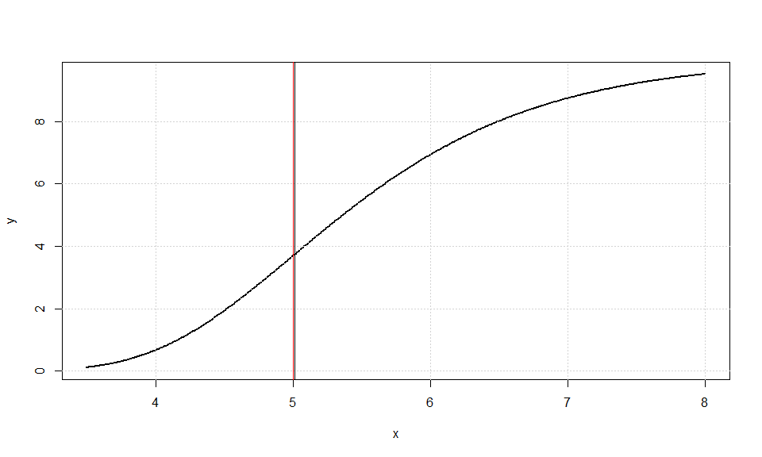

BESE

| n | a | b | ESE |
| --- | --- | --- | --- |
| 501 | 3.500 | 8.000 | 5.0120 |
| 195 | 4.625 | 5.489 | 5.0570 |
| 97 | 4.778 | 5.201 | 4.9895 |
| 48 | 4.904 | 5.120 | 5.0120 |
| 25 | 4.940 | 5.048 | 4.9940 |
| 13 | 4.976 | 5.030 | 5.0030 |
| 7 | 4.985 | 5.012 | 4.9985 |

BEDE

| n | a | b | EDE |
| --- | --- | --- | --- |
| 501 | 3.500 | 8.000 | 5.1920 |
| 245 | 4.454 | 5.669 | 5.0615 |
| 136 | 4.670 | 5.363 | 5.0165 |
| 78 | 4.805 | 5.210 | 5.0075 |
| 46 | 4.886 | 5.120 | 5.0030 |
| 27 | 4.931 | 5.066 | 4.9985 |
| 16 | 4.958 | 5.039 | 4.9985 |
| 10 | 4.976 | 5.021 | 4.9985 |
| 6 | 4.985 | 5.012 | 4.9985 |

## A symmetric 3rd order polynomial with total symmetry

Let the polynomial function:
$$f(x)=-\frac{1}{3}\,x^3+\frac{5}{2}\,x^2-4x+\frac{1}{2}$$
We study it at [-2, 7], it has inflection point at p = 2.5 and we have total symmetry. The SP with 500 sub-intervals without error gives Table 13 of [1] which is absolutely compatible with theoretical predictions. There is no need for any kind of iteration, because both methods agree with the true value.

```r
data("table_13")
x=table_13$x
y=table_13$y
plot(x,y,cex=0.3,pch=19)
grid()
bb=ese(x,y,0);bb
```

```
##      j1  j2 chi
## ESE 126 376 2.5
```

```r
pese=bb[,3];pese
```

```
## [1] 2.5
```

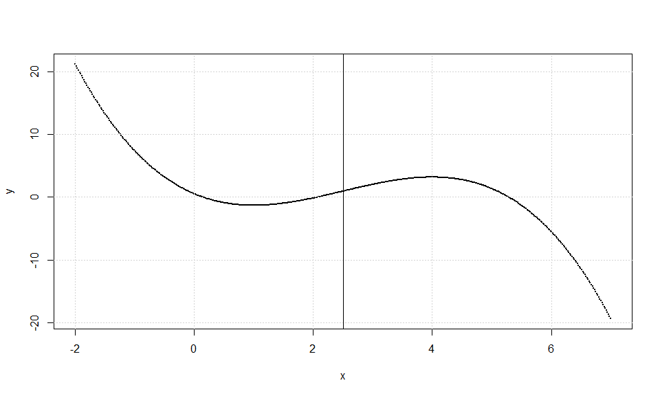

```r
abline(v=pese)
```

The same SP with uniform error distributed by U(−2, 2) gives the results of Table 14 of [1] and two ESE iterations are presented at Table 15 of [1].

```r
data("table_14_15")
x=table_14_15$x
y=table_14_15$y
plot(x,y,cex=0.3,pch=19)
grid()
bb=ese(x,y,0);bb
```

```
##      j1  j2   chi
## ESE 115 375 2.392
```

```r
pese=bb[,3];pese
```

```
## [1] 2.392
```

```r
abline(v=pese)
cc=bese(x,y,0)
cc$iplast
```

```
## [1] 2.473
```

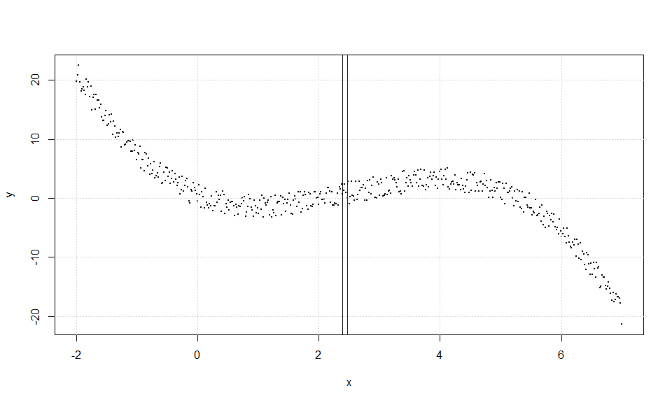

```r
abline(v=cc$iplast,col='blue')
```

```r
knitr::kable(cc$iters, caption = 'BESE')
```

BESE

| n | a | b | ESE |
| --- | --- | --- | --- |
| 501 | -2.000 | 7.000 | 2.392 |
| 261 | 1.222 | 3.688 | 2.455 |
| 138 | 1.564 | 3.382 | 2.473 |

## A symmetric 3rd order polynomial with data right asymmetry

```r
data("table_17_18")
x=table_17_18$x
y=table_17_18$y
bb=ese(x,y,0);bb
```

```
##     j1  j2  chi
## ESE 88 338 2.24
```

```r
pese=bb[,3];pese
```

```
## [1] 2.24
```

```r
plot(x,y,cex=0.3,pch=19)
grid()
cc=bese(x,y,0)
cc$iplast
```

```
## [1] 2.5
```

```r
dd=bede(x,y,0)
dd$iplast
```

```
## [1] 2.5
```

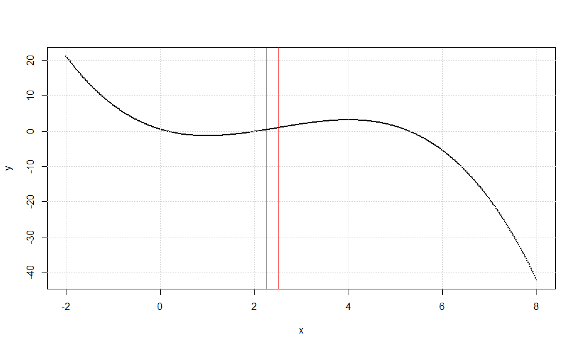

```r
abline(v=pese)
abline(v=cc$iplast,col='blue')
abline(v=dd$iplast,col='red')
```

```r
knitr::kable(cc$iters, caption = 'BESE')
```

BESE

| n | a | b | ESE |
| --- | --- | --- | --- |
| 501 | -2.00 | 8.00 | 2.24 |
| 251 | 1.38 | 3.88 | 2.63 |
| 126 | 1.80 | 3.06 | 2.43 |
| 64 | 2.22 | 2.86 | 2.54 |
| 33 | 2.32 | 2.64 | 2.48 |
| 17 | 2.42 | 2.58 | 2.50 |
| 9 | 2.46 | 2.54 | 2.50 |
| 5 | 2.48 | 2.52 | 2.50 |

```r
knitr::kable(dd$iters, caption = 'BEDE')
```

BEDE

| n | a | b | EDE |
| --- | --- | --- | --- |
| 501 | -2.00 | 8.00 | 2.5 |
| 293 | 0.82 | 4.18 | 2.5 |
| 169 | 1.54 | 3.46 | 2.5 |
| 97 | 1.94 | 3.06 | 2.5 |
| 57 | 2.18 | 2.82 | 2.5 |
| 33 | 2.32 | 2.68 | 2.5 |
| 19 | 2.40 | 2.60 | 2.5 |
| 11 | 2.44 | 2.56 | 2.5 |
| 7 | 2.46 | 2.54 | 2.5 |
| 5 | 2.48 | 2.52 | 2.5 |

We add uniform error distributed by U(-2, 2) and we have the results of Table 19 of [1], while one ESE & one EDE iteration are given at Table 20 of [1].

```r
data("table_19_20")
x=table_19_20$x
y=table_19_20$y
bb=ese(x,y,0);bb
```

```
##     j1  j2  chi
## ESE 88 338 2.24
```

```r
pese=bb[,3];pese
```

```
## [1] 2.24
```

```r
plot(x,y,cex=0.3,pch=19)
grid()
cc=bese(x,y,0)
cc$iplast
```

```
## [1] 2.65
```

```r
dd=bede(x,y,0)
dd$iplast
```

```
## [1] 2.35
```

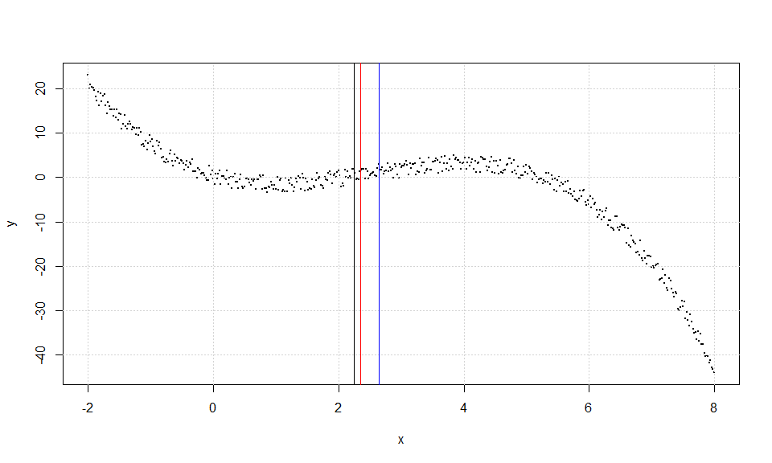

```r
abline(v=pese)
abline(v=cc$iplast,col='blue')
abline(v=dd$iplast,col='red')
```

```r
knitr::kable(cc$iters, caption = 'BESE')
```

BESE

| n | a | b | ESE |
| --- | --- | --- | --- |
| 501 | -2.00 | 8.00 | 2.24 |
| 251 | 1.46 | 3.84 | 2.65 |

```r
knitr::kable(dd$iters, caption = 'BEDE')
```

BEDE

| n | a | b | EDE |
| --- | --- | --- | --- |
| 501 | -2.00 | 8.00 | 2.70 |
| 297 | 0.86 | 3.84 | 2.35 |

There exist a problem here. Although we have a symmetric polyno- mial, the TESE is not equal to the true inflection point. A remedy for this problem for the class of 3rd order polynomials is given with Lemma 2.1 of [1]. Lets apply it here. We have that a = −2, b = 8 and from Table 19 of [1] is $\chi_{r} = −0.26, \chi_{l} = 4.74$, so we have that:
$$\hat{p}=\frac{1}{3}\,\chi_{l} +
\frac{1}{3}\,\chi_{r}+\frac{1}{6}\,a+\frac{1}{6}\,b=2.493333333$$
which is much closer to the true value of 2.5.

## Please send your comments, suggestions or bugs found to dchristop@econ.uoa.gr

## References

[1] Demetris T. Christopoulos (2014), Developing methods for identifying the inflection point of a convex/concave curve. arXiv:1206.5478v2 [math.NA]. URL: https://doi.org/10.48550/arXiv.1206.5478

[2] Demetris T. Christopoulos (2016), On the Efficient Identification of an Inflection Point, International Journal of Mathematics and Scientific Computing , Volume 6 (1), June 2016, Pages 13-20, ISSN: 2231-5330. URL: https://demovtu.veltech.edu.in/wp-content/uploads/2016/04/Paper-04-2016.pdf

[3] J.C. Fisher and R.H. Pry (1971), A Simple Substitution Model of Technological Change, Technological Forecasting and Social Change, 3, pp. 5–88. URL: https://doi.org/10.1016/S0040-1625(71)80005-7

[4] B. Gompertz (1825), On the Nature of the Function Expressive of the Law of Human Mortality, and on a New Mode of Determining the Value of Life Contingencies, Philosophical Transactions of the Royal Society of London, 115, pp. 513–585.